# **Jeu du Mastermind** - Camille Touron L3A

## **Présentation du jeu**

Le Mastermind est un jeu de société pour deux joueurs : un des joueurs (le **codemaker**) invente une combinaison secrète composée de 4 pions de couleurs et son adversaire (le **codebreaker**) doit la trouver par déductions successives, i.e. déterminer la **couleur** et **la position** exacte de chaque pion du code en 12 coups maximum.

Il s'agit d'un jeu de réflexion et de déduction, inventé par Mordecai Meirowitz, expert en télécommunications israëlien, dans les années 1970. Le jeu se base sur un jeu plus ancien (bulls and cows) qui se jouait avec papier et crayon et des nombres au lieu de couleurs.

A l'origine, le codemaker disposait de 6 couleurs différentes (rouge, bleu, noir, jaune, vert, blanc et bleu) pour composer une combinaison de 4 pions. Cependant, des variantes au jeu existent permettant au codemaker d'utiliser jusqu'à 12 couleurs différentes pour composer des combinaisons de 8 pions.

## Les règles du jeu

Le codemaker peut utiliser plusieurs fois la même couleur dans sa combinaison secrète, voire laisser certains emplacements vides (sans pion), ce qui permet de rendre le décodage plus compliqué. Le codebreaker propose à chaque tour une combinaison de pions, qu'il pense être la solution. Le codemaker est alors chargé de *noter* la combinaison proposée en fonction de la combinaison secrète de la façon suivante :

- si l'un des pions de la combinaison proposée correspond par sa POSITION **et** sa COULEUR, le codemaker place un plot **rouge** dans son évaluation;
- si l'un des pions de la combinaison proposée correspond par sa COULEUR **mais** est mal positionné, le codemaker place un plot **blanc** dans son évaluation;
- s'il n'y a aucune correspondance, le codemaker ne place aucun plot dans son évaluation.

### Des exemples pour mieux comprendre ...

On suppose que la combinaison secrète est **RR****V****B**.

- si le codebreaker propose la combinaison **R****V****J****J** : l'évauation sera composée d'un plot rouge (pour le **R** bien placé) et d'un plot blanc (pour le **V** mal placé mais de la bonne couleur).
- si le codebreaker propose la combinaison **B****B****J****N** : l'évaluation sera composée d'un plot blanc uniquement (pour un **B** mal placé). A noter ici que le codemaker ne note pas le second **B**, puisqu'il n'y a qu'un seul **B** dans la combinaison secrète !
- si le codebreaker propose la combinaison **J****N****J****N** : l'évaluation est vide car il n'y a aucune correspondance.

## Objectifs du projet

- Faire jouer un codemaker contre un codebreaker;
- Changer les règles pour complexifier la résolution du jeu;
- Faire jouer l'humain (en tant que codebreaker) contre la machine;
- Créer un algorithme de résolution du jeu en un nombre minimal d'essais (cf Algorithme de **Knuth**).

## Fonctions principales

```python
import random
import sys
import itertools
import matplotlib.pyplot as plt
import numpy as np
import matplotlib.patches

#on définit nos variables : elles peuvent changer en fonction de la difficulté de jeu choisie par les joueurs.
LENGTH = 4
COLORS = ['R', 'V', 'B', 'J', 'N', 'M']#on définit ici les couleurs disponibles pour jouer.
```

On crée une fonction `choices` permettant de renvoyer une combinaison de façon aléatoire à partir du choix de couleurs disponibles et du nombre de pions autorisés. Cette fonction sera utilisée par le codemaker.

```python
def choices(e, n):
    #Renvoie une liste composée de n éléments tirés de e avec remise.
    return [random.choice(e) for i in range(n)]
```

```python
tt = choices(COLORS,LENGTH)
print(tt)
```

```
['N', 'B', 'N', 'R']
```

On se place du côté du codemaker et on crée une fonction `evaluation` permettant de *noter* la combinaison proposée par le codebreaker. La fonction prend en argument l'essai du codebreaker et la combinaison secrète à trouver.

```python
def evaluation(attempt, solution): #Les arguments doivent être des chaînes de caractères
    if len(solution) != len(attempt):
        sys.exit("Erreur : les deux combinaisons n'ont pas la même longueur")
    #on initialise les compteurs
    red = 0 #comptera les plots bien placés et de bonne couleur dans l'essai
    white = 0 #comptera les plots mal placés mais de bonne couleur dans l'essai
    for i in range(len(solution)):
        if solution[i] == attempt[i]: #on compte les plots bien placés
            red += 1
    for i in attempt:
        if i in solution:
            white += 1 #on compte tous les plots présents dans l'essai, bien ou mal placés par rapport à la solution
            solution = solution.replace(i, '', 1) #on remplace une des couleurs dans la solution par des guillemets
            #ainsi on évite que 2 plots de même couleur comptent pour 2 plots présents si cette couleur n'est présente
            #qu'une fois dans solution
    white = white - red
    return red, white
```

```python
ee = evaluation('RBBV','RRBV')
ee
```

```
(3, 0)
```

On crée ensuite une fonction `donner_possibles` qui prend en argument l'essai du codebreaker (sous forme d'une chaine de caractères) et l'évaluation de l'essai et affiche un set contenant toutes les combinaisons compatibles avec l'évaluation donnée par le codemaker. Si on note $S$ la solution et $P$ l'essai, on cherche en fait toutes les combinaisons $Q$ différentes de $P$ telles que $evaluation(P,Q) = evaluation(P,S)$.

```python
def donner_possibles(attempt, evaluation_p):
    possible = set()
    for i in set(itertools.product(COLORS, repeat=LENGTH)):
        if evaluation(attempt, ''.join(i)) == evaluation_p: #on cherche dans le set toutes les combinaisons de couleurs
            #possibles telles que leur évaluation corresponde à l'évaluation du codemaker
            possible.add(i) #on ajoute cette combinaison à l'ensemble des possibles
    return possible
```

On crée une fonction `maj_possibles` qui prend en argument le set des combinaisons possibles, l'essai sous forme d'une chaine de caractères, puis l'évaluation de l'essai. Cette fonction va modifier le set des possibles entré en argument en enlevant toutes les combinaisons incompatibles avec l'évaluation donnée. Nous en aurons besoin dans les programmes suivants.

```python
def maj_possibles(possible, attempt, evaluation_p):
    impossible = set()
    for i in possible:
        if evaluation(attempt, ''.join(i)) != evaluation_p: #si l'évaluation de l'essai avec une combinaison du set
            #des possibles ne correspond pas à l'évaluation de l'essai donnée par le codemaker
            impossible.add(i) #on ajoute cette combinaison de couleurs à l'ensemble des combinaisons impossibles
    for i in impossible:
        possible.remove(i) #on enlève de l'ensemble des possibles, l'ensemble des combinaisons impossibles
```

# Version 1.0 du Mastermind

On crée une première version du jeu simplifiée :

- le codemaker1 choisit une combinaison secrète de façon aléatoire puis évalue les combinaisons proposées par le codebreaker1.
- le codebreaker1 propose une combinaison qu'il choisit de façon **aléatoire** parmi les combinaisons encore non essayées aux tours précédents, sans utiliser vraiment l'évaluation de ses essais précédents.

```python
def codemaker1_init():
    global solution
    solution = ''.join(choices(COLORS, LENGTH)) #on choisit une combinaison de couleurs aléatoire qui sera la solution
    #print(solution)


def codemaker1(attempt):
    global solution
    red, white = evaluation(attempt, solution) #on évalue la combinaison proposée par le joueur adverse.
    return(red, white)
```

```python
def codebreaker1_init():
    global possible
    possible = set(itertools.product(COLORS, repeat=LENGTH))

#on fait le produit cartésien de COLORS par lui même LENGTH fois
#on utilise un type set car l'ordre n'est pas important


def codebreaker1(evaluation_p):
    global possible
    attempt = possible.pop() #on prend un élément aléatoire --car possible est du type set-- dans possible
    return ''.join(attempt) #on renvoie une chaine de 4 caractères
```

### Codebreaker1 VS Codemaker1

On fait jouer codemaker1 contre codebreaker1

```python
#DECOMMENTER POUR VOIR L'AFFICHAGE DE LA PARTIE
def play1_1():
    """
    Fonction principale de ce programme :
    Fait jouer ensemble le codebreaker1 et le codemaker1
    """
    n_tries = 0
    codebreaker1_init()
    codemaker1_init()
    evaluation_p = None
    #print('Combinaisons de taille {}, couleurs disponibles {}'.format(LENGTH, COLORS))
    while True:
        attempt = codebreaker1(evaluation_p)
        (red, white) = codemaker1(attempt)
        n_tries += 1
        #print("Essai {} : {} ({},{})".format(n_tries, attempt, red, white))
        evaluation_p = (red, white)
        if red >= LENGTH:
            #print("Bravo ! Trouvé {} en {} essais".format(attempt, n_tries))
            return n_tries
```

```python
play1_1()
```

```
1091
```

### Statistiques

On pose :

- L’événement $A$ : « La combinaison testée est correcte » ; $P(A) = \frac{1}{COLORS^{LENGTH}} = \frac{1}{6^4} = \frac{1}{1296}$
- La variable aléatoire $X$ qui compte le nombre d’essais avant de trouver la bonne combinaison. L'évènement $[X = k]$ $\forall k \in [0,\frac{1}{C^L}]$ est l'union des évènements : " la combinaison testée à chacun des (k-1) premiers essais est fausse " **et** " la combinaison testée au kème essai est correcte ". $P(X = k) = \frac{C^L-1}{C^L}\times\frac{C^L-2}{C^L-1}\times$ ... $\times\frac{C^L-(k-1)}{C^L-(k-2)}\times\frac{1}{C^L-(k-1)} = \frac{1}{C^L}$ $E(X) = \sum_{0}^{C^L}k\times P(X=k) = \frac{1}{C^L}\times\sum_{0}^{C^L}k = \frac{1}{C^L}\times\frac{C^L(C^L+1)}{2} = \frac{C^L+1}{2} = \frac{1296+1}{2} = 648,5$

```
Moyenne = 630.005
```

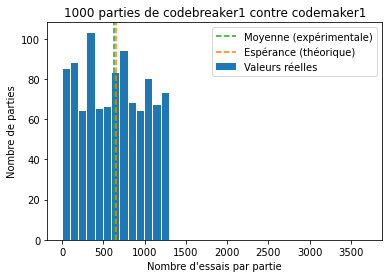

```python
''' Cette fonction assure l affichage de plusieurs parties de Mastermind entre codebreaker1 et codemaker1 '''

nb_parties = 1000 #on décide d'un nombre de parties assez grand
X = []

for i in range(nb_parties):
    X.append(play1_1())#on ajoute le nombre d'essais qu'il a fallu pour trouver la solution

Moyenne = sum(X)/nb_parties
print("Moyenne =", Moyenne)#on affiche la moyenne expérimentale pour comparer avec l'espérance théorique

largeur = 100 #on choisit une largeur pour les rectangles de l'histogramme

plt.hist(X, bins = range(0, 3800, largeur), rwidth=0.9)
#on construit un histogramme qui affiche pour chaque partie le nombre d'essais nécessaires pour trouver la combinaison secrète
#on trace les probabilités théoriques

plt.axvline(x = Moyenne, color = 'tab:green', linestyle = 'dashed')
plt.axvline(x = (len(COLORS)**LENGTH + 1)/2,  color = 'tab:orange', linestyle = 'dashed')

plt.title("{} parties de codebreaker{} contre codemaker{}".format(nb_parties, 1, 1))
plt.xlabel("Nombre d'essais par partie")
plt.ylabel("Nombre de parties")
plt.legend(["Moyenne (expérimentale)", "Espérance (théorique)", "Valeurs réelles"])
plt.show()
```

# Version 2.0 du Mastermind

Nous allons complexifier le jeu en modifiant légèrement les règles :

- le codemaker2 cherche à rallonger la partie afin d'éviter que le codebreaker ne trouve la solution trop vite. Pour cela, il **modifie à chaque tour** sa solution (combinaison secrète d'origine) en respectant la dernière évaluation mais de façon à ce que l'ensemble des combinaisons compatibles avec l'évaluation soit le plus grand possible. Cependant, la nouvelle solution ne respectera pas forcément les évaluations des tours précédents.
- le codebreaker2 ne propose plus sa solution de façon aléatoire : à chaque tour, il propose un nouvel essai choisi aléatoirement parmi une liste de combinaisons possibles **mise à jour en fonction de l'évaluation donnée au tour précédent**.

```python
def codemaker2_init():
    global solution
    global possible
    solution = ''.join(choices(COLORS, LENGTH))
    possible = set(itertools.product(COLORS, repeat=LENGTH)) #le codemaker crée un ensemble possible
    #car il n'a pas accès à  celui du codebreaker


def codemaker2(attempt):
    global solution
    global possible

    score_solution = score_codemaker2(attempt, solution)
    #on place dans score_solution le score de la solution entrée par rapport à l'essai

    for i in possible:
        i = ''.join(i) #on choisit une combinaison qui fera office de solution provisoire
        score_i = score_codemaker2(attempt, i) #on calcule le score de cette solution par rapport à l'essai
        if (score_i > score_solution) or (score_i == score_solution and random.randint(0,1) == 1):
            #si ce score est supérieur au score de la solution précédente
            solution = i #la solution prend la valeur i
            score_solution = score_i #le score prend la valeur du nouveau score
    #print(solution)
    red, white = evaluation(attempt, solution) #on détermine l'évaluation à  partir de cette nouvelle solution
    maj_possibles(possible, attempt, (red, white)) #on met à jour possible pour le tour suivant
    return red, white


def score_codemaker2(attempt, solution): #les arguments sont de type str
    '''
    Fonction principale de ce programme :
    Calculer le nombre de combinaisons compatibles avec une solution entrée en argument
    (i.e celles qui ont la même évaluation avec l'essai du codebreaker que cet essai avec la combinaison solution).
    Codemaker2 choisit alors la solution qui est compatible avec le maximum d'éléments de 'possible'
    '''
    global possible

    evaluation_p = evaluation(attempt, solution) #on évalue l'essai par rapport à la solution provisoire
    count = 0

    for i in possible:
        if evaluation(attempt, ''.join(i)) == evaluation_p:
            #si l'évaluation de la combinaison choisie dans possible correspond à celle donnée précédemment
            count += 1 #on compte cette combinaison car elle serait gardée si on utilisait maj_possibles
    return count
```

```python
def codebreaker2_init():
    global possible
    possible = set(itertools.product(COLORS, repeat=LENGTH))


def codebreaker2(evaluation_p):
    global possible
    global attempt #on passe l'essai en variable globale pour s'en souvenir au tour suivant et interpréter l'évaluation
    if evaluation_p != None: #on a déjà  fait un premier essai
        maj_possibles(possible, attempt, evaluation_p) #on met à jour les possibles en cohérence avec l'essai
    possible = list(possible)
    attempt = random.choice(possible) #on choisit le prochain essai
    possible.remove(attempt)
    possible = set(possible) #on retransforme possible en set pour appliquer la fonction maj_possibles
    return ''.join(attempt) #on renvoie un essai de l'ensemble des possibles mis à jour.
```

### Cobreaker2 VS Codemaker2

Il est temps de faire jouer codemaker2 contre codebreaker2 !

```python
#DECOMMENTER LES LIGNES POUR VOIR L'AFFICHAGE DE LA PARTIE / COMMENTER POUR CONSTRUIRE L'HISTOGRAMME
def play2_2():
    """
    Fonction principale de ce programme :
    Fait jouer ensemble le codebreaker2 et le codemaker2
    """
    n_tries = 0
    codebreaker2_init()
    codemaker2_init()
    evaluation_p = None
    #print('Combinaisons de taille {}, couleurs disponibles {}'.format(LENGTH, COLORS))
    while True:
        attempt = codebreaker2(evaluation_p)
        (red, white) = codemaker2(attempt)
        n_tries += 1
        #print("Essai {} : {} ({},{})".format(n_tries, attempt, red, white))
        evaluation_p = (red, white)
        if red >= LENGTH:
            print("Bravo ! Trouvé {} en {} essais".format(attempt, n_tries))
            return n_tries
```

```python
for p in range(3):
    play2_2()
```

[output not shown]

### Codebreaker2 VS Codemaker1

On peut aussi comparer les résultats en faisant jouer codemaker1 contre codebreaker2.

```python
#DECOMMENTER POUR VOIR L'AFFICHAGE DE LA PARTIE
def play1_2():
    """
    Fonction principale de ce programme :
    Fait jouer ensemble le codebreaker2 et le codemaker1
    """
    n_tries = 0
    codebreaker2_init()
    codemaker1_init()
    evaluation_p = None
    #print('Combinaisons de taille {}, couleurs disponibles {}'.format(LENGTH, COLORS))
    while True:
        attempt = codebreaker2(evaluation_p)
        (red, white) = codemaker1(attempt)
        n_tries += 1
        #print("Essai {} : {} ({},{})".format(n_tries, attempt, red, white))
        evaluation_p = (red, white)
        if red >= LENGTH:
            #print("Bravo ! Trouvé {} en {} essais".format(attempt, n_tries))
            return n_tries #on renvoie le nb d'essais
```

```python
play1_2()
```

```
4
```

### Statistiques

En comparant les jeux entre codebreaker2 et codemaker 1 ou 2, on obtient un histogramme semblable à celui-ci : on voit que codemaker2 complexifie la résolution du jeu !

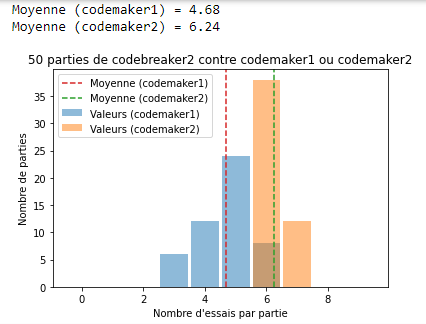

[output not shown]

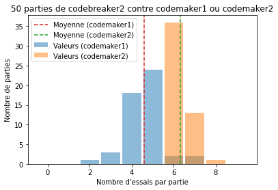

```python
'''
Fonction principale du programme :
Afficher le nombre d essais nécesssaires à codebreaker2 lors de chaque partie pour trouver la solution
Comparer les résultats pour des parties contre codemaker1 ou codemaker2.
'''

nb_parties = 50
X = []
Z=[]


for i in range(nb_parties):
    X.append(play1_2())
    Z.append(play2_2())

#affichage des moyennes
Moyenne_x = sum(X)/nb_parties
print("Moyenne (codemaker1) =", Moyenne_x)
Moyenne_z = sum(Z)/nb_parties
print("Moyenne (codemaker2) =", Moyenne_z)

xmin = 0
xmax = 9

plt.hist(X, bins = np.linspace(xmin - 0.5, xmax + 0.5, xmax - xmin + 2), rwidth=0.9, alpha = 0.5)
plt.hist(Z, bins = np.linspace(xmin - 0.5, xmax + 0.5, xmax - xmin + 2), rwidth = 0.9, alpha = 0.5)

plt.axvline(x = Moyenne_x, color = 'tab:red', linestyle = 'dashed')
plt.axvline(x = Moyenne_z, color = 'tab:green', linestyle = 'dashed')

plt.title("{} parties de codebreaker{} contre codemaker{} ou codemaker{}".format(nb_parties, 2, 1, 2))
plt.xlabel("Nombre d'essais par partie")
plt.ylabel("Nombre de parties")
plt.legend(["Moyenne (codemaker1)", "Moyenne (codemaker2)", "Valeurs (codemaker1)", "Valeurs (codemaker2)"])
plt.show()
```

# Version 3.0 du Mastermind

Nous essayons de rendre le décodage de la combinaison secrète optimal, en utilisant l'**algorithme de Knuth**. David Knuth est à l'origine du Five Guess. Selon lui, il serait possible de décoder toute combinaison secrète en 5 essais maximum en suivant une méthode particulière. Dans son [essai](https://www.cs.uni.edu/~wallingf/teaching/cs3530/resources/knuth-mastermind.pdf) de 1977, il démontre sa proposition pour un jeu du Mastermind avec des combinaisons à 4 pions parmi 6 couleurs possibles. Voici l'algorithme. 1) on essaie une première combinaison et on obtient une évaluation. Le choix de la 1ere combinaison a son importance;

2) on met à jour le set des combinaisons compatibles avec cette évaluation, noté `maj_possibles`;

3) on parcourt l'ensemble des essais restants, càd les $6^4$ combinaisons moins celles déjà utilisées. Pour chaque essai restant, noté $P$, et pour chaque évaluation possible notée $E$ ((0,1), (0,2), (0,3) etc ...) on calcule le nombre de combinaisons de `maj_possibles` dont l'évaluation avec $P$ est exactement $E$. On choisit ensuite le **maximum** de ces scores intermédiaires. On répète cette opération pour l'ensemble des combinaisons restantes. Ce maximum sera le score de $P$.

4) on choisit la combinaison avec le score **miminum** : si plusieurs combinaisons ont le même score on peut garder la première combinaison rencontrée. Cette combinaison sera proposée comme essai au prochain tour. La combinaison choisie n'est pas forcément dans `maj_possibles` mais l'algorithme fonctionne quand même.

```python
LENGTH = 4
COLORS = ['R', 'V', 'B','N','M','O']

def codebreaker31_init():
    global D #on a besoin de variables globales pour D et possible car les sets évoluent au cours de la partie
    global possible
    global not_tried
    possible = set(itertools.product(COLORS, repeat=LENGTH))
    D = set(itertools.product(COLORS, repeat=LENGTH)) #D représente l'ensemble des combinaisons inutilisées par codebreaker3

def codebreaker31(evaluation_p):
    global D
    global possible
    global essai

    if evaluation_p != None: #s'il n'y a pas d'évaluation c'est qu'on en est au premier tour de jeu
        maj_possibles(possible, essai, evaluation_p) #on met à  jour les possibles en cohérence avec l'essai précédent
    if len(possible) == 1: #si il ne reste qu'une possibilité, on connaît la solution
        essai = possible.pop()
        return ''.join(essai)
    else:
        score_attempt = len(possible) #si une combinaison obtient ce score, c'est qu'elle ne donne aucune nouvelle information
        for i in D : #cet ensemble est identique à possible en début de partie
            score_i = score_codebreaker_31(i)
            if (score_i < score_attempt): #on ne garde que la combinaison dont le score est le plus faible
                essai = i
                score_attempt = score_i
        possible.discard(essai) #si la partie continue, alors on saura que cet essai n'est pas possible
        D.discard(essai)
    return ''.join(essai) #on renvoie l'essai avec le score le plus faible de l'ensemble des possibles mis à jour.


def score_codebreaker_31(essai): #l'argument est un tuple, c'est un élément de l'ensemble de départ

    '''Fonction du programme :
    Pour chaque élément de possible P, la fonction calcule le nb de combinaisons restantes dans maj_possibles
    pour chaque score (rouge,blanc) en supposant que P soit la solution.
    Le score de P sera le nb **maximum** de combinaisons restants dans maj_possibles pour une évaluation donnée (rouge,blanc)
    '''

    global possible
    A = [(0,0),(0,1),(0,2),(0,3),(0,4),(1,0),(1,1),(1,2),(1,3),(2,0),(2,1),(2,2),(3,0),(4,0)]
    # liste de tous les scores possibles
    essai = ''.join(essai)
    count_max = 0
    for k in range (len(A)) : #on parcourt les évaluations possibles
        evaluation_pro = A[k] #on prend une évaluation en particulier
        count = 0
        for j in possible: #on parcourt tous les essais compatibles avec l'évaluation du codemaker1
            if evaluation(essai, ''.join(j)) == evaluation_pro:
                count += 1
        if count > count_max: #on choisit le maximum qui sera le score associé à un élément de possible
            count_max = count
    return count_max
```

### Codebreaker3 VS Codemaker1

On fait jouer codebreaker3 contre codemaker1.

```python
#DECOMMENTER POUR VOIR L'AFFICHAGE DE LA PARTIE

def play1_3():
    global essai
    """
    Fonction principale de ce programme :
    Fait jouer ensemble le codebreaker3 et le codemaker1
    """
    n_tries = 0
    codebreaker31_init()
    codemaker1_init()

    evaluation_p = None
    #print('Combinaisons de taille {}, couleurs disponibles {}'.format(LENGTH, COLORS))
    while True:
        if n_tries ==0:
            essai = 'RRVV'
        else:
            essai = codebreaker31(evaluation_p)
        (red, white) = codemaker1(essai)
        n_tries += 1
        #print("Essai {} : {} ({},{})".format(n_tries, essai, red, white))
        evaluation_p = (red, white)
        if red >= LENGTH:
            print("Bravo ! Trouvé {} en {} essais".format(essai, n_tries))
            return n_tries #on renvoie le nb d'essais
```

```python
play1_3()
```

```
Bravo ! Trouvé NORO en 4 essais
```

```
4
```

### Statistiques

L'algorithme devrait nous donner une moyenne **inférieure à 5 essais** par partie pour trouver la solution du codemaker. Comme cet algorithme cherche à minimiser le nombre d'essais de codebreaker3, il est assez long : codebreaker3 va parcourir plusieurs fois le set des possibles.

```
Bravo ! Trouvé RNON en 5 essais
Bravo ! Trouvé BBOR en 5 essais
Bravo ! Trouvé MMBR en 5 essais
Bravo ! Trouvé OMVV en 5 essais
Bravo ! Trouvé RVVM en 4 essais
Moyenne (codebreaker3) = 4.8
```

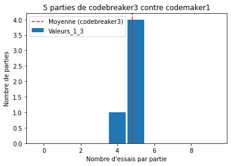

```python
'''
Fonction principale du programme :
Afficher le nombre d essais nécesssaires à codebreaker3 lors de chaque partie contre codemaker1 pour trouver la solution
'''

#ATTENTION : ALGORITHME LONG!

nb_parties = 5 #l'algorithme est long car codebreaker3 va parcourir plusieurs fois le set de possibles
Y = []

for i in range(nb_parties):
    Y.append(play1_3())

#affichage des moyennes
Moyenne_y = sum(Y)/nb_parties
print("Moyenne (codebreaker3) =", Moyenne_y)

xmin = 0
xmax = 9

plt.hist(Y, bins = np.linspace(xmin - 0.5, xmax + 0.5, xmax - xmin + 2), rwidth = 0.9)

plt.axvline(x = Moyenne_y, color = 'tab:red', linestyle = 'dashed')


plt.title("{} parties de codebreaker{} contre codemaker{}".format(nb_parties, 3, 1))
plt.xlabel("Nombre d'essais par partie")
plt.ylabel("Nombre de parties")
plt.legend(["Moyenne (codebreaker3)", "Valeurs_1_3"])
plt.show()
```

# Version humain contre machine

Pour s'amuser on peut aussi faire jouer l'humain contre la machine : nous choisissons ici **codemaker1** de façon à ce que la solution choisie au départ ne change pas au cours de la partie et donc que les évaluations successives permettent à l'humain de décoder la combinaison secrète.

```python
dico_color = {'R': 'red', 'V':'green', 'B':'blue', 'J':'yellow', 'N':'black', 'M':'brown', 'O':'orange', 'G':'grey'}

def creation_image(dico_essai):

    """Partie graphique du jeu, affichage de chaque essai
    """

    figure = plt.figure(figsize = (6,6)) #on crée la grille
    axes = plt.gca(title = 'Mastermind')
    centres_y = np.linspace(0,1,14)[1:-1] #on crée les centres des cercles
    centres_x = np.linspace(0,0.4,6)[1:-1]
    for i in range (len(centres_x)):
        for j in range (len(centres_y)):
            if j in dico_essai: #on affiche le cercle de la bonne couleur
                axes.add_artist(matplotlib.patches.Circle((centres_x[i],centres_y[11-j]),0.03, color = f'{dico_color[dico_essai[j][0][i]]}', ec = 'black'))
                for a in range(dico_essai[j][1][0]):#on affiche les plots bien placés
                    axes.add_artist(matplotlib.patches.Circle((centres_x[a]+0.5,centres_y[11-j]),0.01, color = 'red', ec = 'black'))
                for b in range(dico_essai[j][1][1]):#on affiche les plots mal placés
                    axes.add_artist(matplotlib.patches.Circle((centres_x[dico_essai[j][1][0]+b]+0.5,centres_y[11-j]),0.01, color = 'silver', ec = 'black'))
                for c in range(dico_essai[j][1][0] + dico_essai[j][1][1], 4):#on affiche les plots restants
                    axes.add_artist(matplotlib.patches.Circle((centres_x[c]+0.5,centres_y[11-j]),0.01, color = 'white', ec = 'black'))
            else:#on affiche les essais restants en blanc
                axes.add_artist(matplotlib.patches.Circle((centres_x[i],centres_y[11-j]),0.03, color = 'white', ec = 'black'))
                axes.add_artist(matplotlib.patches.Circle((centres_x[i]+0.5,centres_y[11-j]),0.01, color = 'white', ec='black'))
    plt.show()#on montre l'image
```

```python
def play_human_against_codemaker1():
    """
    Fonction principale du programme:
    Fait jouer l'utilisateur humain (au clavier) dans le role du codebreaker
    contre codemaker1
    """
    dico_essai = {}
    # dico_essai associe au numero de l'essai un tuple de la forme (essai, correction)
    n_tries = 0
    codemaker1_init()
    evaluation_p = None
    print('Combinaisons de taille {}, couleurs disponibles {}'.format(LENGTH, COLORS))
    while True:

        attempt = input("Saisir combinaison: ")
        #On entre directement une combinaison au clavier
        if len(attempt) != 4:
            print("Combinaison invalide (pas la bonne taille)")
            continue
        (red, white) = codemaker1(attempt)
        correction = (red, white)
        dico_essai[n_tries] = (attempt,correction)

        n_tries += 1
        print("Essai {} : {} ({},{})".format(n_tries, attempt, red, white))
        creation_image(dico_essai)
        evaluation_p = (red, white)
        if red >= LENGTH:
            print("Bravo ! Trouvé {} en {} essais".format(attempt, n_tries))
            break
```

```
Combinaisons de taille 4, couleurs disponibles ['R', 'V', 'B', 'N', 'M', 'O']
Saisir combinaison: BBNN
Essai 1 : BBNN (1,1)
```

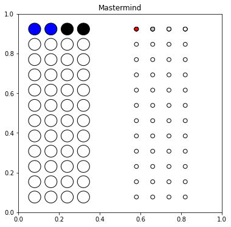

```
Saisir combinaison: BJJB
Essai 2 : BJJB (0,0)
```

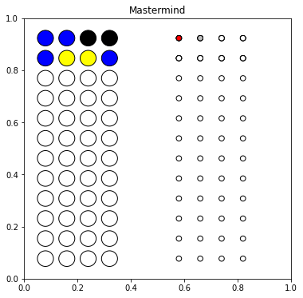

```
Saisir combinaison: NRRN
Essai 3 : NRRN (2,0)
```

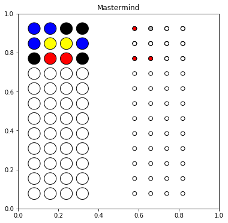

```
Saisir combinaison: NMVN
Essai 4 : NMVN (3,0)
```

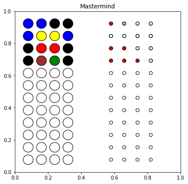

```
Saisir combinaison: NMON
Essai 5 : NMON (3,0)
```

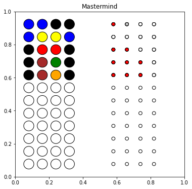

```
Saisir combinaison: NMMN
Essai 6 : NMMN (4,0)
```

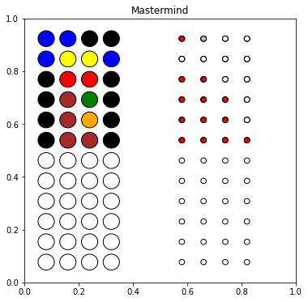

```
Bravo ! Trouvé NMMN en 6 essais
```

```python
play_human_against_codemaker1()
```